# 多變量 Gaussian Mixture Model 與 GMM Skill

# 14 Skill 的架構

```
.claude/skills/multivariate-gmm/
├── SKILL.md          何時啟用、整體流程、CLI、每個關卡要呈現什麼
├── references/       規格與清單，需要時才讀（progressive disclosure）
├── scripts/          R 程式，負責所有計算
├── tests/            自動化測試
└── example_data/     示範資料
```

| 元件 | 角色 | 數量 |
| --- | --- | --- |
| `SKILL.md` | frontmatter 的 `description` 決定何時啟用，本文規定流程 | 1 |
| `references/` | Decision Tree、Stage 規格、Outcome contract、待審清單 | 18 份 |
| `scripts/` | 計算與流程控制 | 14 支 |
| `tests/` | 公式、流程、誠實性 | 863 項檢查 |

| 腳本 | 功能 |
| --- | --- |
| `data_import.R` | 唯讀 preview 與確認後的 import |
| `data_stage2.R`、`eda_stage2.R`、`knn_audit.R` | 缺失診斷與處理、EDA、KNN 稽核 |
| `feasibility_stage3.R` | Stage 3 檢查與核准規格 |
| `em_stage4.R` | EM 核心與初始化 |
| `select_stage4.R` | 收斂診斷與 BIC/AIC |
| `confirm_stage4.R` | 收斂確認（診斷用） |
| `interpret_stage5.R` | 解釋與不確定性 |
| `validate_stage6.R` | 穩定性、敏感度、外部驗證、剖繪 |
| `workflow.R`、`sensitivity_workflow.R` | 狀態機、關卡、模型登記、敏感度流程 |
| `warnings_registry.R`、`report_final.R` | 限制紀錄與最終報告 |

**為什麼用 base R 自己寫 EM？** 為了完全掌握每一步的有效性檢查與失敗紀錄。mclust 只用在 `tests/` 當獨立驗證，不參與正式估計。

**註釋文件與程式不一致時以程式為準**

部分 `references/` 文件保留了開發早期的狀態描述，待修清單在 § 24。本文的說明都以實作為準。

# 15 Approval Gates

Approval Gates 有兩種，強度不同：**R 程式強制**的關卡，沒有核准旗標就會 REFUSED；**`SKILL.md` 指示**的關卡，則靠 Claude 遵守流程，程式本身只檢查順序。

| 關卡 | 呈現給使用者 | 需要的動作 | 強制方式 |
| --- | --- | --- | --- |
| `preview` → `import` | 大小、欄位、缺失標記 | 確認設定，`--approved true` 與 `--approval-ref` | R 程式 |
| `new-run` | 分析變數、目標 | `--approved true` 與 `--approval-ref` | R 程式 |
| `stage2` | EDA、缺失型態 | 從選單選方法 | `SKILL.md`（選單內容）；處理需下一列 |
| `stage2-handle` | 處理後摘要；或 KNN 暫停選單 | `--approved true` | R 程式 |
| `stage3` | 檢查與待決定事項 | 尺度、獨立性、$G$，`--approved true` | R 程式；`stage4` 要求已核准規格 |
| `stage4`、`stage5`、`stage6` | 收斂、BIC/AIC、解釋、驗證 | 使用者確認 | **`SKILL.md`**；程式只檢查順序 |
| `stage6-replay` | 重跑設定 | `--approved true` | R 程式 |
| `sensitivity-plan` | 差異、初始化方法、工作量 | `sensitivity-run --approved true` 與 `--approval-ref` | R 程式 |
| `sensitivity-run` | 與 Active Model 的比較、所有警告 | `activate-model --approved true` 或 `sensitivity-close` | R 程式 |

`--approved true` 只能在使用者於對話中明確核准該動作後才傳入，而且**核准不能把 BLOCKED 變成 SUCCESS**。

# 16 Workflow、Candidate Model 與 Active Model

一個分析對應一個目錄與一份 `workflow_state.json`。每個命令只做一個 Stage，並在最後印出下一步。

- **Active Model**：Stage 5、6 與報告唯一讀取的模型。第一次 `stage4` 的結果會成為 Active。
- **Candidate Model**：已登記但未啟用的模型。模型 ID 是 `G<g>-<selected_model.rds 雜湊前 12 碼>`。
- **切換只有一條路**：`activate-model --approved true`，且會先做完整性檢查。最佳 BIC 不會自動取代 Active。

```
stateDiagram-v2
  [*] --> PLANNED: sensitivity-plan
  PLANNED --> RUNNING: 使用者核准 sensitivity-run
  PLANNED --> WITHDRAWN: 撤回
  RUNNING --> FIT_COMPLETED
  RUNNING --> BLOCKED: 無有效模型
  FIT_COMPLETED --> CONFIRMED: 收斂確認
  FIT_COMPLETED --> CANDIDATE_REGISTERED: tol 已夠嚴
  CONFIRMED --> CANDIDATE_REGISTERED
  CONFIRMED --> NO_NEW_CANDIDATE: 與既有模型相同
  CANDIDATE_REGISTERED --> CLOSED_KEEP_ACTIVE: 保留 Active
  FIT_COMPLETED --> NO_NEW_CANDIDATE: 與既有模型相同
  CANDIDATE_REGISTERED --> [*]: activate-model
  RUNNING --> FAILED: 擬合失敗
  FIT_COMPLETED --> FAILED: 確認、比較或驗證失敗
  CONFIRMED --> FAILED: 比較或驗證失敗
  FAILED --> WITHDRAWN: 撤回
  BLOCKED --> WITHDRAWN: 撤回
```

尚未結束的狀態（`RUNNING`、`FIT_COMPLETED`、`CONFIRMED`）也可以用 `sensitivity-close --decision withdraw` 撤回，圖中省略；中斷的執行無法原地續跑。

一個計畫只用一種初始化方法。`plan.json` 記錄設定、`init_spec`、`rng_kind` 與資料雜湊；內容被改動就拒絕執行，擬合方法與計畫不符也不會登記。

# 17 F7 Outcome Contract：錯誤、BLOCKED 與 PAUSE

這三者常被混為一談，但處理方式完全不同。

| Outcome | Exit | 意義 | 例子 | 怎麼處理 |
| --- | --- | --- | --- | --- |
| `SUCCESS` | 0 | 完成；WARNING 也算成功但要揭露 | Stage 完成 | 進行下一步 |
| `AWAITING_USER_APPROVAL` | 2 | **正常關卡**，輸出已完成 | 缺失選單、KNN 暫停 | 使用者決定 |
| `BLOCKED` | 3 | **統計或資料判斷**：此請求無法估計 | Stage 3 STOP、Inf、無有效模型 | 修改設計，核准無效 |
| `ERROR` | 1 | 程式或輸入失敗 | 參數不合法 | 修正指令或錯誤 |
| `REFUSED` | 4 | 現在不允許 | 順序錯、缺核准、檔案被改 | 補足前置條件 |

REFUSED 通常發生在任何計算之前。例外是敏感度執行途中的完整性檢查失敗：已完成的輸出會保留，計畫標記為 `FAILED`，命令的 Outcome 為 REFUSED。

`workflow.R`、`data_import.R`、`data_stage2.R`、`feasibility_stage3.R`、`select_stage4.R` 會在最後印出可機器讀取的 `Outcome`、`Exit-Code`、`Stage`、`Code`、`Next-Action`。獨立呼叫 Stage 5、Stage 6、report、registry、收斂確認與 KNN 稽核的 CLI，目前只有 exit code 0 與 1，沒有這些行；透過 `workflow.R` 執行 Stage 5、6 時則有。

# 18 R、CLI、測試與可重現性

**CLI。** 從專案根目錄執行：

```bash
Rscript .claude/skills/multivariate-gmm/scripts/workflow.R stage4 --root results/<name>
```

**可重現性的做法**

- **種子排程**：起點 $s$ 用 $421+s-1$，`with_seed()` 還原全域亂數狀態，RNG 種類記在每個起點。
- **綁定資料**：`spec_hash`、`approval_id`、資料與模型檔的雜湊。
- **不覆寫**：輸出先寫到 staging 目錄，驗證後才移入；非空目錄一律拒絕。
- **replay**：`confirm_stage4` 與 Stage 6 replay 依紀錄重現起點，不一致就停止。

診斷資料

**來源** `tutorial/evidence/test-run/full_regression_summary.txt（F13 驗收時的完整回歸，保存副本）`

**設定** R 4.5.1；863 項檢查

**適用範圍** 代表該次執行時的測試狀態；Skill 在該次之後未再修改

| 測試結果 |
| --- |
| Stage 2 (32 checks). |
| Stage 2 EDA (34 checks). |
| Stage 3 (45 checks). |
| Stage 4A-4B EM (35 checks). |
| Stage 4C-4D (28 checks). |
| 54 confirmation. |
| Stage 5 (30 checks). |
| Stage 6 (33 checks). |
| workflow integration (33 checks). |
| model registry (34 checks). |
| 64 warnings-registry. |
| 74 data-import. |
| 55 KNN-audit. |
| 70 status-contract. |
| sensitivity workflow (117 checks). |
| 76 initialisation. |
| 49 Stage 6 report. |

測試不只檢查公式，也檢查誠實性：例如不合法的 `--init` 必須回報 ERROR、未核准不得執行、報告不得出現不適用的資料集文字、k-means 結果必須與舊版完全相同。mclust 的比較也寫在測試中。

# Part IV — Real Data Analysis and Workflow Demonstration

# 19 Palmer Penguins

已核准正式結果

**來源** `results/penguins/（stage2、stage3/approved、stage4/selection-G1-5、stage5/interpretation-G3、stage6/validation-G3-vs-G4-with-replay）；圖表取自 final-report-registry/`

**設定** G = 1–5，20 starts，seed 421，tol 1e-6，max_iter 1000，k-means，z-score，VVV

**適用範圍** 逐模組執行並逐階段核准；無 workflow_state.json。外部標籤 species 僅用於 Stage 6

## 19.1 資料與問題

資料來自 Horst 等 (2020年) 與 Gorman 等 (2014年)，共 344 列。四個連續變數（`bill_length_mm`、`bill_depth_mm`、`flipper_length_mm`、`body_mass_g`）進入模型；`species` 保留為外部標籤，**不參與估計**。

## 19.2 Stage 2：缺失與 EDA

| 變數 | 缺失數 | 缺失率 |
| --- | --- | --- |
| bill_length_mm | 2 | 0.0058 |
| bill_depth_mm | 2 | 0.0058 |
| flipper_length_mm | 2 | 0.0058 |
| body_mass_g | 2 | 0.0058 |

缺失型態只有兩種：完整，或四個變數全缺。全缺的列（來源列 4、272）沒有資訊可以插補，使用者核准 complete-case，保留 342 列。

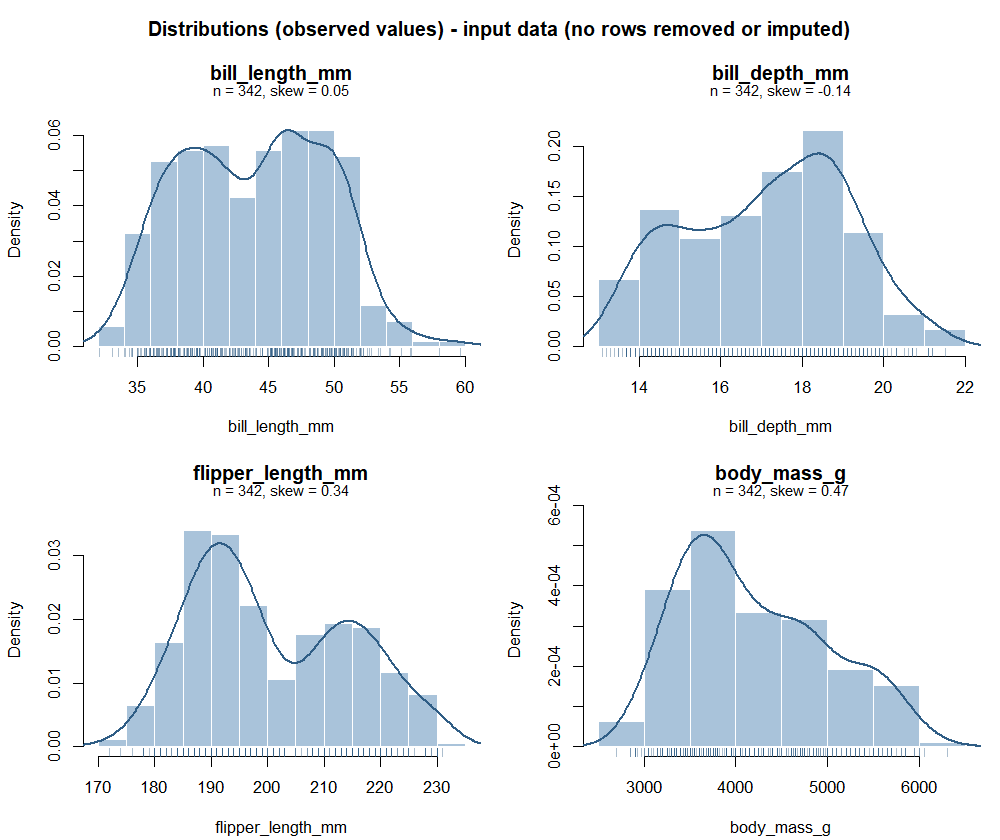

四個變數的分布

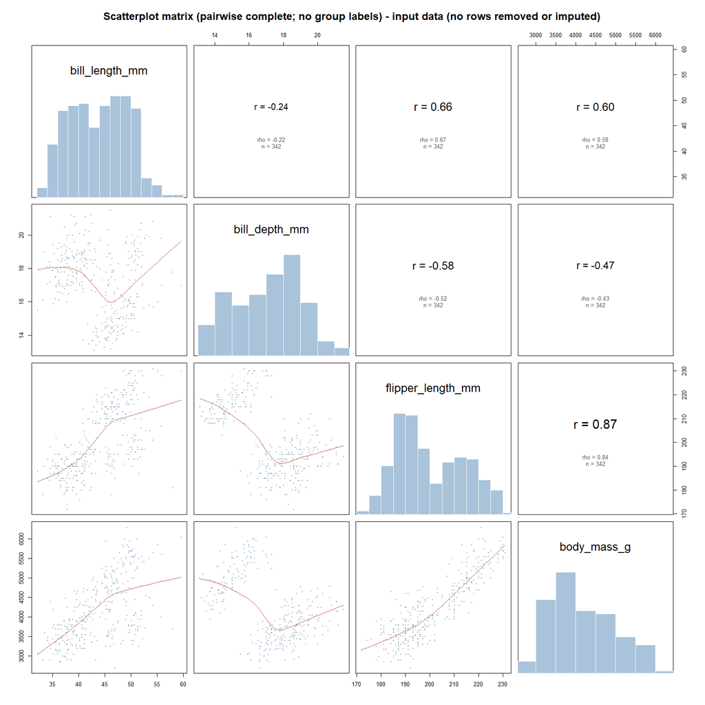

散佈圖矩陣

## 19.3 Stage 3：可行性

| 狀態 | 檢查數 |
| --- | --- |
| PASS | 12 |
| WARNING | 3 |

三個 WARNING 是離群值篩選（S3-07）、$G=5$ 的成分樣本偏少（S3-11），以及列獨立性（S3-14）。獨立性是 working assumption，來自 Stage 3 核准規格：個體 ID 重複出現，無法排除重複量測。

## 19.4 Stage 4：BIC 與 AIC

表 1: Penguins 各 G 的模型比較

| G | k | loglik | BIC | ΔBIC | AIC | ΔAIC | 有效起點 | 達最佳 | 局部解 |
| --- | --- | --- | --- | --- | --- | --- | --- | --- | --- |
| 1 | 14 | -1516.15 | 3113.99 | 564.38 | 3060.30 | 690.02 | 1 | 1 | 1 |
| 2 | 29 | -1206.79 | 2582.79 | 33.19 | 2471.58 | 101.30 | 20 | 20 | 1 |
| 3 | 44 | -1146.43 | 2549.60 | 0.00 | 2380.87 | 10.59 | 20 | 15 | 2 |
| 4 | 59 | -1126.14 | 2596.53 | 46.93 | 2370.28 | 0.00 | 20 | 10 | 4 |
| 5 | 74 | -1111.19 | 2654.15 | 104.55 | 2370.37 | 0.09 | 20 | 6 | 7 |

BIC 選 $G=3$，AIC 偏好 $G=4$。AIC 的懲罰每個參數為 2，BIC 為 $\log n=$ 5.83，所以 AIC 傾向較大的 $G$。$G=3$ 有 2 個局部解，20 個起點中 15 個到達最佳。

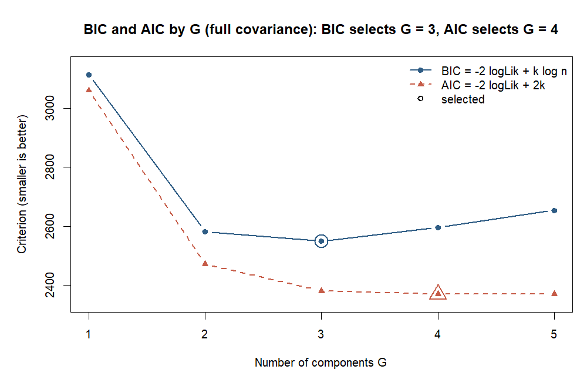

BIC 與 AIC

## 19.5 Stage 5：成分解釋

表 2: Penguins G = 3 的成分（原始單位）

| 成分 | π | 有效 n | MAP 列數 | bill length | bill depth | flipper | body mass |
| --- | --- | --- | --- | --- | --- | --- | --- |
| 1 | 0.445 | 152.384 | 152 | 38.81 | 18.32 | 189.71 | 3691.61 |
| 2 | 0.360 | 123.000 | 123 | 47.50 | 14.98 | 217.19 | 5076.02 |
| 3 | 0.195 | 66.616 | 67 | 48.99 | 18.48 | 196.51 | 3754.44 |

$\pi$ 與 MAP 比例非常接近，表示成分重疊很少；整體平均不確定性為 0.00864，最大為 0.442。成分 2 嘴喙較淺、鰭肢較長、體重較重。**這裡只描述參數，不替成分命名。**

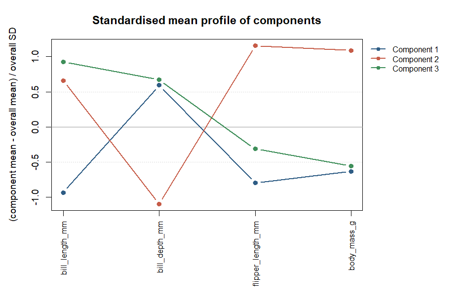

標準化平均剖面

## 19.6 Stage 6：驗證

表 3: 成分與外部標籤的交叉表（僅事後比較）

| 成分 | Adelie | Chinstrap | Gentoo |
| --- | --- | --- | --- |
| 1 | 149 | 3 | 0 |
| 2 | 0 | 0 | 123 |
| 3 | 2 | 65 | 0 |

選定模型的 ARI $=$ 0.9603，NMI $=$ 0.9349，替代模型 $G=4$ 的 ARI $=$ 0.8191。一致性很高，但 **標籤不用於重新選 $G$，而 Gaussian 成分也不因此被證明就是物種**。Substantive interpretation 仍為 not established。

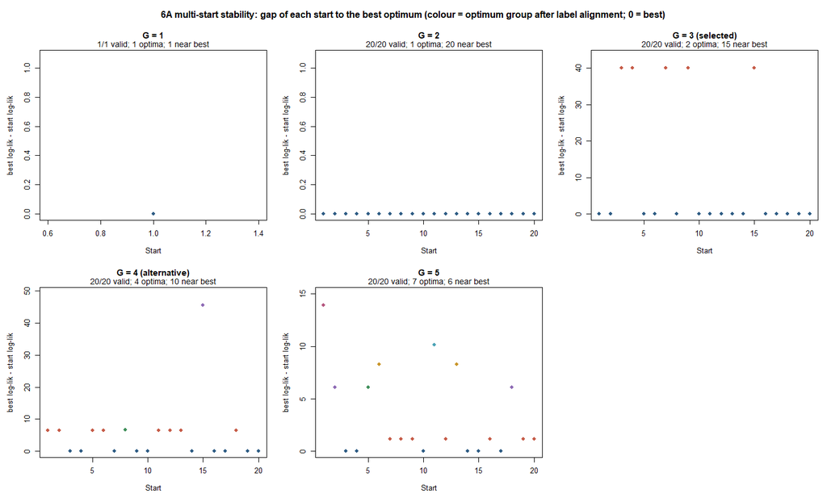

多起點穩定性

穩定性方面，$G=3$ 達最佳的起點比例為 0.75，同一最佳解內的分割 ARI 為 1.000；納入其他局部解後平均 ARI 降到 0.811，說明局部解確實對應不同分割。

# 20 UCI Automobile

這個案例的價值在於**結論不穩定**：它展示 KNN 插補、局部最佳解、數值穩定與 $G$ 選擇的不確定性。分析變數為 `engine-size`、`horsepower`、`curb-weight`、`city-mpg`，$n=205$，$p=4$ (Schlimmer 1985年)。Make 與 price 沒有當作真實標籤，所以 6C 為 Not Performed。

## 20.1 證據層級總覽

| 結果 | 層級 | 地位 |
| --- | --- | --- |
| 原始 workflow Stage 4，$G=5$ | 已核准正式結果 | 仍是 `workflow_state.json` 指向的模型 |
| 敏感度工作模型，$G=5$ | 已核准工作模型 | 核准用於 Stage 5–6 與報告，不取代上列 |
| 收斂確認 | 診斷資料 | 說明原始模型為何偏低，本身不換模型 |
| mclust VVV | 驗證對照 | 只比較，不估計 |
| F9 初始化試算 | 未採用的暫存區試算 | 未核准，未登記 |

## 20.2 Stage 2：KNN 插補

已核准正式結果

**來源** `results/automobile/workflow/stage2-knn/；donor 稽核 results/automobile/stage2-knn-audit/`

**設定** KNN，k = 5，由使用者核准

**適用範圍** horsepower 兩格單一插補；不反映插補不確定性

| 順位 | donor 來源列 | 距離 | donor horsepower | 與前一名同距 |
| --- | --- | --- | --- | --- |
| 1 | 29 | 0.2955 | 88 | FALSE |
| 2 | 124 | 0.2955 | 88 | TRUE |
| 3 | 1 | 0.3138 | 111 | FALSE |
| 4 | 2 | 0.3138 | 111 | TRUE |
| 5 | 170 | 0.3714 | 116 | FALSE |

來源列 131、132 的 horsepower 缺失。`knn_audit` 顯示兩格的插補值都是 102.8，稽核檔的 `n_distinct_donor_profiles` 為 3，表示這些 donor 中有規格相同的列。這個值只是描述，**不是有效樣本數**。這兩列屬於同一品牌，donor 全來自其他品牌，這是核准紀錄明列的限制。

## 20.3 原始 Stage 4 與敏感度工作模型

已核准正式結果

**來源** `results/automobile/workflow/stage4-selection/`

**設定** 20 starts，seed 421，tol 1e-6，max_iter 1000，k-means

**適用範圍** 已核准的 Stage 4 模型

已核准工作模型

**來源** `results/automobile/stage4-sensitivity/；核准紀錄 results/automobile/sensitivity_model_approval_record.md`

**設定** 100 starts，seed 421，tol 1e-8，max_iter 5000，k-means

**適用範圍** 核准作為 Stage 5 的工作模型，Stage 6 與報告另經使用者確認；不取代上一個模型

診斷資料

**來源** `results/automobile/stage4-confirmation-tol1e-8/`

**設定** 續跑原 20 起點至 tol 1e-8

**適用範圍** 診斷；不換模型

表 4: 原始 Stage 4、工作模型與收斂確認的 log-likelihood

| G | k | 原始 ℓ | 工作模型 ℓ | 確認後 ℓ | 原始 BIC | 工作模型 BIC | 工作模型有效起點 | 局部解 |
| --- | --- | --- | --- | --- | --- | --- | --- | --- |
| 1 | 14 | -780.718 | -780.718 | -780.718 | 1635.96 | 1635.96 | 1/1 | 1 |
| 2 | 29 | -571.486 | -571.485 | -571.485 | 1297.34 | 1297.34 | 100/100 | 1 |
| 3 | 44 | -495.931 | -495.930 | -495.930 | 1226.07 | 1226.07 | 100/100 | 2 |
| 4 | 59 | -422.167 | -422.166 | -422.166 | 1158.39 | 1158.39 | 97/100 | 4 |
| 5 | 74 | -364.741 | -359.771 | -359.771 | 1123.39 | 1113.44 | 91/100 | 13 |

這裡有兩個不同的量，不能混用：

- **最佳值的變化。** `tol = 1e-6` 下 $G=5$ 的最佳值是 -364.741（起點 1）。同一組 20 個起點續跑到 `tol = 1e-8` 後，最佳值變成 -359.771，但達到它的是**另一個**起點（起點 5）。兩個最佳值相差 4.97，$\Delta$BIC 為 -9.94。
- **同一起點的增益。** 起點 5、15 原本停在 -366.622，續跑後增加 6.85，被標為 `POSSIBLE_PREMATURE_STOP`。原本的最佳起點則沒有實質變化。

也就是說，**「收斂」只代表停止規則被滿足**。

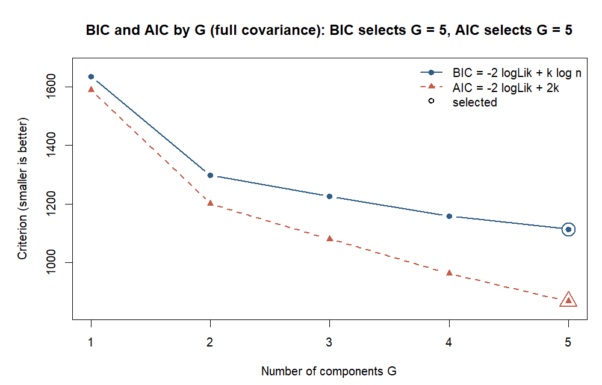

敏感度工作模型的 BIC 與 AIC

BIC 與 AIC 都選 $G=5$，而 5 正是搜尋上界，屬於邊界解。

## 20.4 Stage 5 與 Stage 6（工作模型）

表 5: Automobile 工作模型 G = 5 的成分（原始單位）

| 成分 | π | 有效 n | MAP | 模糊列 | engine-size | horsepower | curb-weight | city-mpg |
| --- | --- | --- | --- | --- | --- | --- | --- | --- |
| 1 | 0.304 | 62.250 | 60 | 4 | 128.0 | 104.9 | 2694.3 | 24.1 |
| 2 | 0.242 | 49.673 | 52 | 8 | 102.0 | 75.3 | 2116.7 | 29.1 |
| 3 | 0.178 | 36.462 | 35 | 4 | 99.3 | 68.2 | 2127.7 | 33.4 |
| 4 | 0.143 | 29.303 | 30 | 5 | 187.1 | 163.5 | 3261.2 | 17.1 |
| 5 | 0.133 | 27.312 | 28 | 5 | 142.1 | 139.8 | 2851.7 | 18.5 |

每個成分的有效樣本都低於 Stage 3 的 $5\times14$ 建議值。穩定性也弱：100 個起點中有 91 個有效，形成 13 個局部解，只有 3 個到達最佳。替代模型 $G=4$ 與工作模型的 ARI 為 0.793。

## 20.5 mclust 驗證對照

mclust 驗證對照

**來源** `results/automobile/stage4-mclust-comparison/em_vs_mclust.csv`

**設定** mclust::Mclust(G, VVV)；tight 列兩邊 tol 皆 1e-12

**適用範圍** 只比較數值；mclust 不參與正式估計，也不是核准模型

表 6: 本流程與 mclust 的 log-likelihood（tight 設定）

| G | 本流程 | mclust | 差 | 誰較高 |
| --- | --- | --- | --- | --- |
| 1 | -780.718 | -780.718 | 0.000 | 相同 |
| 2 | -571.485 | -591.164 | 19.679 | 本流程較高 |
| 3 | -495.930 | -510.323 | 14.393 | 本流程較高 |
| 4 | -422.166 | -415.496 | -6.670 | mclust 較高 |
| 5 | -359.771 | -378.765 | 18.995 | 本流程較高 |

只有 $G=4$ 是 mclust 較高，這正是 F9 的起點。兩者最大化同一個概似，所以初始化是主要懷疑對象。下面的暫存區試算用 mclust (Scrucca 等 2016年) 的 `hc` 分割當作單一起點，接上 Skill 未修改的 EM 來檢驗這一點。

未採用的暫存區試算

**來源** `tutorial/evidence/f9-initialization/data/f9_mb_auto.csv；腳本 scripts/f9_trial_mb.R；紀錄 logs/f9_mb_auto.log`

**設定** mclust::hc(modelName = “VVV”, use = “SVD”) 的分割作為單一起點，接 Skill 的 em_run；Stage 3 核准資料；tol 1e-8，max_iter 5000

**適用範圍** 只檢驗初始化能否解釋差距。未核准、未登記；mclust 不參與正式估計

表 7: mclust 階層分割接上 Skill EM，與 mclust 本身的結果（未採用的暫存區試算）

| G | 狀態 | Skill EM（mclust 分割起點） | mclust VVV | 差 |
| --- | --- | --- | --- | --- |
| 2 | CONVERGED_VALID | -591.1637 | -591.1637 | -4.9e-06 |
| 3 | CONVERGED_VALID | -510.3235 | -510.3235 | -5.0e-05 |
| 4 | CONVERGED_VALID | -415.4961 | -415.4961 | -8.2e-06 |
| 5 | CONVERGED_VALID | -378.7654 | -378.7654 | -2.0e-05 |

在 $G=2$ 到 $5$，兩者的最大絕對差為 5e-05。這支持「差距主要來自初始化」，但只是這份資料上的試算。

## 20.6 F9 初始化試算（未採用）

未採用的暫存區試算

**來源** `tutorial/evidence/f9-initialization/（暫存區試算的副本，SHA-256 於渲染時驗證）`

**設定** Stage 3 核准資料，G = 2–5，每法 1000 起點（Ward 為 1），seed 421 + s − 1，tol 1e-8，max_iter 5000，min_effective_n 5，max_cov_condition 1e10

**適用範圍** 敏感度證據。未核准、未登記為 Candidate，不取代 Active Model 或正式報告；不能宣稱已找到最佳的非退化解

表 8: 相同起點預算（1000）的比較，不含 Ward

| G | 方法 | 有效 | 無效起點 | 退化 | 最佳 ℓ | 命中 | 局部解 | BIC | AIC | 最小 Nk | 最大條件數 | 最小特徵值 |
| --- | --- | --- | --- | --- | --- | --- | --- | --- | --- | --- | --- | --- |
| 3 | kmeans | 1000 | 0 | 0 | -495.9302 | 0 | 2 | 1226.07 | 1079.86 | 26.07 | 1947.0 | 0.0017900 |
| 3 | random | 1000 | 0 | 0 | -481.1232 | 5 | 207 | 1196.46 | 1050.25 | 50.01 | 187.5 | 0.0019410 |
| 3 | random-soft | 1000 | 0 | 0 | -481.1232 | 4 | 155 | 1196.46 | 1050.25 | 50.01 | 187.5 | 0.0019410 |
| 4 | kmeans | 975 | 25 | 0 | -422.1663 | 0 | 5 | 1158.39 | 962.33 | 35.44 | 191.0 | 0.0019770 |
| 4 | random | 988 | 0 | 12 | -412.9162 | 0 | 714 | 1139.89 | 943.83 | 24.97 | 10780.0 | 0.0000976 |
| 4 | random-soft | 995 | 0 | 5 | -410.1981 | 1 | 609 | 1134.45 | 938.40 | 32.34 | 8965.0 | 0.0000863 |
| 5 | kmeans | 922 | 78 | 0 | -359.7705 | 0 | 23 | 1113.44 | 867.54 | 27.31 | 871.9 | 0.0019470 |
| 5 | random | 967 | 0 | 33 | -361.9443 | 0 | 935 | 1117.79 | 871.89 | 27.44 | 1935.0 | 0.0004351 |
| 5 | random-soft | 976 | 0 | 24 | -356.0761 | 2 | 889 | 1106.05 | 860.15 | 18.00 | 11410.0 | 0.0001893 |

表 9: 起點預算對最佳 ℓ 與 BIC 選擇的影響（同一組種子的前 20、100、1000 起點）

| 方法 | 起點數 | G=3 ℓ | G=4 ℓ | G=5 ℓ | BIC 選 | AIC 選 |
| --- | --- | --- | --- | --- | --- | --- |
| kmeans | 20 | -495.9302 | -422.1663 | -359.7705 | 5 | 5 |
| kmeans | 100 | -495.9302 | -422.1663 | -359.7705 | 5 | 5 |
| kmeans | 1000 | -495.9302 | -422.1663 | -359.7705 | 5 | 5 |
| random | 20 | -482.5234 | -412.9162 | -376.5177 | 4 | 5 |
| random | 100 | -482.5234 | -412.9162 | -371.0757 | 5 | 5 |
| random | 1000 | -481.1232 | -412.9162 | -361.9443 | 5 | 5 |
| random-soft | 20 | -487.8627 | -416.1872 | -382.0878 | 4 | 5 |
| random-soft | 100 | -487.8627 | -416.1872 | -372.9807 | 5 | 5 |
| random-soft | 1000 | -481.1232 | -410.1981 | -356.0761 | 5 | 5 |

**顯示程式碼**

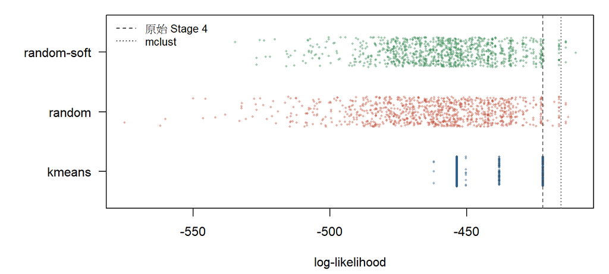

圖 5: G = 4 每個有效起點的 log-likelihood（未採用的暫存區試算）。k-means 集中在少數解，隨機方法分散且偶爾更高。

```r
all <- do.call(rbind, lapply(c('kmeans', 'random', 'random-soft'), function(m) { d <- rd(EV(sprintf('data/f9a_auto_%s.csv', m))); d[d$G == 4 & d$status == 'CONVERGED_VALID', c('method', 'loglik')] }))
op <- par(mar = c(4.3, 7, 1, 1)); set.seed(1); y <- match(all$method, c('kmeans', 'random', 'random-soft'))
plot(all$loglik, y + runif(nrow(all), -.25, .25), pch = 16, cex = .45, col = adjustcolor(PAL[y], .45), yaxt = 'n', ylab = '', xlab = 'log-likelihood', ylim = c(.5, 3.5)); axis(2, 1:3, c('kmeans', 'random', 'random-soft'), las = 1); abline(v = c(g(aw, 4, 'loglik'), amc$loglik_mclust[amc$G == 4 & grepl('tight', amc$setting)]), lty = c(2, 3), col = 'grey30'); legend('topleft', c('原始 Stage 4', 'mclust'), lty = c(2, 3), bty = 'n', cex = .85); par(op)
```

**Ward 單一起點只作參考，不與上表比較：**

| G | ℓ | BIC | AIC | 最小 Nk | 最大條件數 | 最小特徵值 |
| --- | --- | --- | --- | --- | --- | --- |
| 2 | -571.4846 | 1297.34 | 1200.97 | 93.49 | 78.31 | 0.0129600 |
| 3 | -525.8425 | 1285.90 | 1139.68 | 7.00 | 13750.00 | 0.0000957 |
| 4 | -471.2496 | 1256.56 | 1060.50 | 7.00 | 13750.00 | 0.0000957 |
| 5 | -410.3793 | 1214.66 | 968.76 | 7.00 | 13750.00 | 0.0000957 |

從這些試算可以學到：

1. **沒有方法全面勝出。** 1000 起點時 random-soft 在 $G=3,4,5$ 最高；但 20 起點時 $G=5$ 反而 k-means 最高。
2. **最佳解很難碰到。** 最佳已知解最多只被命中幾次，不能宣稱已找到最佳的非退化解。
3. **$G$ 的選擇會變。** 20 起點時隨機方法的 BIC 選 $G=4$，100、1000 起點時選 $G=5$。
4. **較高的 likelihood 不等於較好。** 見下一節。

### 20.6.1 數值上可疑但符合現行標準的解

表 10: 通過全部有效性檢查、但有窄成分的解（未採用的暫存區試算）

| 方法 | G | 起點數 | ℓ | 最小 Nk | 最大條件數 | 最小特徵值 |
| --- | --- | --- | --- | --- | --- | --- |
| ward | 3 | 1 | -525.8425 | 7.00 | 13750 | 0.0000957 |
| random | 4 | 100 | -412.9162 | 24.97 | 10780 | 0.0000976 |
| random | 4 | 1000 | -412.9162 | 24.97 | 10780 | 0.0000976 |
| random-soft | 4 | 1000 | -410.1981 | 32.34 | 8965 | 0.0000863 |
| ward | 4 | 1 | -471.2496 | 7.00 | 13750 | 0.0000957 |
| random-soft | 5 | 100 | -372.9807 | 7.00 | 198800 | 0.0000145 |
| random-soft | 5 | 1000 | -356.0761 | 18.00 | 11410 | 0.0001893 |
| ward | 5 | 1 | -410.3793 | 7.00 | 13750 | 0.0000957 |

表 11: 全部有效起點中條件數最高的五個解（未採用的暫存區試算）

| 方法 | G | 起點 | ℓ | 最小 Nk | 最大條件數 | 最小特徵值 |
| --- | --- | --- | --- | --- | --- | --- |
| random | 5 | 198 | -436.447 | 8.99 | 1.746e+08 | 5.05e-08 |
| random | 5 | 556 | -373.257 | 5.98 | 1.124e+08 | 7.92e-08 |
| random | 3 | 924 | -518.932 | 9.00 | 3.030e+07 | 1.28e-07 |
| random | 5 | 815 | -386.573 | 9.00 | 3.029e+07 | 1.28e-07 |
| random-soft | 5 | 35 | -402.656 | 5.86 | 2.999e+07 | 3.40e-07 |

上表說明，只看各方法的最佳解會低估搜尋過程的數值風險：11,823 個有效起點中，最大條件數達 1.75e+08，仍低於失效門檻，也沒有成為各 $G$ 的最佳解。

作為對照，工作模型的最大條件數是 871.9。上表的解都低於失效門檻 $10^{10}$，所以 Skill 不會判定無效；但 § 5.1 告訴我們，高 likelihood 可能只是因為有一個成分很窄。這類解應該連同成分大小與條件數一起判斷，由分析者決定。

# 21 新版 Workflow 示範

教學示範（模擬核准）

**來源** `tutorial/demo/（tutorial/demo/results/demo-missing/runs/R-20261109-155855-01）；由 tutorial/R/run_demo.R 產生，渲染時不重跑`

**設定** Skill 內建 example_data/missing.csv（3 變數）；G = 1–4；k-means 20 starts；敏感度計畫 random-soft 20 starts、tol 1e-7

**適用範圍** 所有核准都是教學用途的模擬，不是使用者的分析決定；與 Penguins、Automobile 無關，不修改任何正式 Active Model

示範依序走過 `preview → import → new-run → Stage 1–6 → report`，再走 `sensitivity-plan`。下表是實際執行紀錄，刻意包含被拒絕與被阻擋的情境。

表 12: 示範的 27 個命令與 Outcome

| # | 步驟 | Outcome | Exit | Code |
| --- | --- | --- | --- | --- |
| 1 | preview | SUCCESS | 0 | PREVIEW_READ_ONLY |
| 2 | import without approval | REFUSED | 4 | PRECONDITION_NOT_MET |
| 3 | import with undeclared NA text | AWAITING_USER_APPROVAL | 2 | IMPORT_UNDECLARED_MISSING_LIKE |
| 4 | import | SUCCESS | 0 | IMPORTED |
| 5 | new-run | SUCCESS | 0 | CREATED |
| 6 | stage3 before stage2 (wrong order) | REFUSED | 4 | PRECONDITION_NOT_MET |
| 7 | stage2 diagnostics and EDA | AWAITING_USER_APPROVAL | 2 | MISSING_DATA_CHOICE |
| 8 | stage2-handle without approval | REFUSED | 4 | PRECONDITION_NOT_MET |
| 9 | KNN pause: all-missing rows | AWAITING_USER_APPROVAL | 2 | KNN_ALL_MISSING_ROWS |
| 10 | KNN with the listed rows dropped | SUCCESS | 0 | PROCESSED_AWAITING_GMM_APPROVAL |
| 11 | stage3 first run: decisions needed | AWAITING_USER_APPROVAL | 2 | STAGE3_DECISIONS_REQUIRED |
| 12 | stage3 with reported dependence | BLOCKED | 3 | STAGE3_STOP |
| 13 | stage4 before stage3 approval | REFUSED | 4 | PRECONDITION_NOT_MET |
| 14 | stage3 approved (teaching) | SUCCESS | 0 | APPROVED_FOR_FIT |
| 15 | stage4 with a plan-only method | REFUSED | 4 | PRECONDITION_NOT_MET |
| 16 | stage4 | SUCCESS | 0 | PASS |
| 17 | stage5 | SUCCESS | 0 | DONE |
| 18 | stage6 | SUCCESS | 0 | DONE |
| 19 | report | SUCCESS | 0 | DONE |
| 20 | sensitivity-plan with unsupported init | ERROR | 1 | EXECUTION_ERROR |
| 21 | sensitivity-plan random-soft | AWAITING_USER_APPROVAL | 2 | SENSITIVITY_PLAN_APPROVAL |
| 22 | sensitivity-run without approval | REFUSED | 4 | PRECONDITION_NOT_MET |
| 23 | sensitivity-run (teaching approval) | AWAITING_USER_APPROVAL | 2 | ACTIVE_MODEL_DECISION |
| 24 | activate-model without approval | REFUSED | 4 | PRECONDITION_NOT_MET |
| 25 | sensitivity-status | SUCCESS | 0 | OK |
| 26 | sensitivity-close keep-active | SUCCESS | 0 | SENSITIVITY_KEEP_ACTIVE |
| 27 | models | SUCCESS | 0 | OK |

| Outcome | 次數 |
| --- | --- |
| AWAITING_USER_APPROVAL | 6 |
| BLOCKED | 1 |
| ERROR | 1 |
| REFUSED | 7 |
| SUCCESS | 12 |

**註釋教學核准與正式 Approval Reference 的差別**

示範的核准是模擬，不是分析決定。`new-run`、`sensitivity-run`、`sensitivity-close` 有 `--approval-ref` 欄位，紀錄中寫明 TUTORIAL DEMO ONLY。`stage2-handle` 與 `stage3` 的命令沒有這個欄位，所以 `workflow_state.json` 裡這兩筆只有核准項目；其中 Stage 3 的獨立性註記標明教學用途，Stage 2 的紀錄本身沒有。教學用途由 `demo_info.json` 與本節的來源框記錄。正式分析中，核准必須來自使用者在對話中的明確確認。

## 21.1 代表性情境

**等待核准：缺失選單**

```
$ Rscript workflow.R stage2-handle --root tutorial/demo/results/demo-missing/runs/R-20261109-155855-01 --method knn --k 5 --approved true

Status: PAUSE
PAUSE [KNN_ALL_MISSING_ROWS]: 1 observation(s) have every selected variable missing (source rows: 129). KNN has no predictor for them.
KNN was not run and no files were written. Ask the user to choose:
  A. Drop these rows and continue KNN on the remaining rows: rerun with --all-missing-action drop --approved true
  B. Cancel KNN and return to the missing-data handling menu (complete-case / mean / median / KNN / diagnostics)
  C. Output missing-data diagnostics only: rerun with --method diagnostics
Next: USER CHOICE: stage2-handle --method complete-case|mean|median|knn|diagnostics-only (processing needs --approved true) [last PAUSE: KNN_ALL_MISSI
Outcome: AWAITING_USER_APPROVAL
Exit-Code: 2
Stage: stage2
Code: KNN_ALL_MISSING_ROWS
Next-Action: USER CHOICE: stage2-handle --method complete-case|mean|median|knn|diagnostics-only (processing needs --approved true) [last PAUSE: KNN_AL

[process exit code] 2
```

KNN 發現有全部變數都缺失的列，於是暫停並列出，等使用者決定，什麼都不寫。

**BLOCKED：回報觀測相依**

```
$ Rscript workflow.R stage3 --root tutorial/demo/results/demo-missing/runs/R-20261109-155855-01 --g 1:4 --scale zscore --rows-independent false --appr

Status: STOP
Outstanding:
  - S3-14 Rows are independent observation units [STOP]: User reports dependence (repeated or clustered units)
Output: ./tutorial/demo/results/demo-missing/runs/R-20261109-155855-01/stage3-check-2
Next: BLOCKED at Stage 3; approval cannot bypass a STOP. Options: Check the study design. Only if the user can justify it, rerun stage3 with --rows-in
Outcome: BLOCKED
Exit-Code: 3
Stage: stage3
Code: STAGE3_STOP
Next-Action: BLOCKED at Stage 3; approval cannot bypass a STOP. Options: Check the study design. Only if the user can justify it, rerun stage3 with --

[process exit code] 3
```

使用者回報資料有相依，S3-14 為 STOP。這是統計判斷，帶著 `--approved true` 也不會通過。

**REFUSED：順序錯誤**

```
$ Rscript workflow.R stage3 --root tutorial/demo/results/demo-missing/runs/R-20261109-155855-01

Refused: Run stage2 first.
Outcome: REFUSED
Exit-Code: 4
Stage: stage3
Code: PRECONDITION_NOT_MET
Next-Action: Satisfy the stated precondition, then rerun.

[process exit code] 4
```

Stage 2 還沒做就要求 Stage 3，什麼都不執行。

**ERROR：參數不合法**

```
$ Rscript workflow.R sensitivity-plan --root tutorial/demo/results/demo-missing/runs/R-20261109-155855-01 --init nope

Error: --init must be one of kmeans, random, random-soft, ward, received: nope
Outcome: ERROR
Exit-Code: 1
Stage: sensitivity-plan
Code: EXECUTION_ERROR
Next-Action: Correct the problem shown in the error, then rerun.

[process exit code] 1
```

`--init nope` 不是合法的初始化方法，是輸入錯誤，不是統計判斷。

## 21.2 敏感度計畫與 Candidate

```
$ Rscript workflow.R sensitivity-plan --root tutorial/demo/results/demo-missing/runs/R-20261109-155855-01 --init random-soft --n-starts 20 --tol 1e-7

Status: AWAITING_APPROVAL
Plan S-20261109-155930-01. Active model G3-e89ba4e4637d stays active.
  changed tol: 1e-06 -> 1e-07
  changed init: kmeans -> random-soft
Initialisation: active model kmeans; this plan random-soft (CHANGED).
  responsibilities: soft; algorithm: each row ~ Dirichlet(1,...,1), from independent Gamma(1, 1) draws normalised by row; adjustable_parameters: none;
  random number generator: Mersenne-Twister/Inversion/Rejection; start s uses seed 421 + s - 1
  unchanged min_effective_n: 4; max_cov_condition: 1e+10
Workload: 60 EM solves + 1 closed-form fit(s); iteration upper bound 60,000; indicative 864 (active mean 14.4 per start).
Indicative only: based on the active model's iterations; a tighter tol usually needs more. The convergence confirmation replays and continues every va
Convergence confirmation: WILL_RUN (fit tol 1e-07 is above the approved strict_tol 1e-08).
A higher log-likelihood alone does not make a model more reliable: the full-covariance Gaussian mixture likelihood is unbounded as a covariance collap
Approving this plan covers the fit, the diagnostic confirmation and registering a valid fit as a candidate. It does not change the active model.
Output: ./tutorial/demo/results/demo-missing/runs/R-20261109-155855-01/sensitivity/S-20261109-155930-01
Next: USER APPROVAL: sensitivity-run --plan S-20261109-155930-01 --approval-ref "..." --approved true, or sensitivity-close --plan S-20261109-155930-0
Outcome: AWAITING_USER_APPROVAL
Exit-Code: 2
Stage: sensitivity-plan
Code: SENSITIVITY_PLAN_APPROVAL
Next-Action: USER APPROVAL: sensitivity-run --plan S-20261109-155930-01 --approval-ref "..." --approved true, or sensitivity-close --plan S-20261109-1

[process exit code] 2
```

核准後的擬合產生 Candidate G3-44ff723cc908。執行前後 Active Model 都是 G3-e89ba4e4637d，因為示範選擇 `keep-active`，沒有呼叫 `activate-model`。

# Part V — Limitations, Development History and References

# 22 統計與實作限制

**統計限制**

- 未受約束 GMM 一般不存在全域最大概似解；多起點只能增加找到較佳非退化解的機會。
- 高 likelihood 可能來自窄成分，見 § 5.1。
- BIC 在混合模型上缺乏完整理論基礎，邊界解不會自動擴大搜尋。
- Gaussian 成分不一定是自然群組；posterior 不等於分類準確率。
- 單一插補不反映不確定性；缺失機制無法由資料證明。
- 觀測獨立性無法由資料證明，兩個案例都是 working assumption。

**尚未實作，本文沒有當作已具備**：bootstrap／subsampling、split-sample 驗證、missing-data EM、multiple imputation、其他 covariance family、covariance regularization、Bayesian GMM。

**待審的專案門檻。** `references/pending-heuristics.md` 列出 41 項，全部 PENDING REVIEW，例如 $p+1$、$10^{10}$、$\Delta\mathrm{BIC}\le6$、$U>0.10$、Dirichlet(1,…,1)。它們都不是教科書規則，改動需要核准並重跑相關階段。

**Automobile 的現況**：`workflow_state.json` 建立於模型登記機制之前，只能讀取，未遷移。

# 23 開發歷程：F1–F13 驗收

開發採「一次一個發現、先設計再實作、每一步等待確認」的節奏，紀錄在 `results/automobile/acceptance_log.md`。全部項目已由使用者確認。

| 項目 | 問題 | 結果 |
| --- | --- | --- |
| F1–F3 | 匯入、唯讀預覽、分析資料夾 | `data_import.R`、`new-run`、`runs` |
| F4 | KNN donor 無法追蹤 | 每次 KNN 寫出稽核檔 |
| F5–F6 | 限制無法帶到報告 | `warnings_registry.R`，部分修正 |
| F7 | 狀態碼語意混淆 | Outcome Contract（§ 17） |
| F8、F12 | `tol = 1e-6` 可能過早停止 | `confirm_stage4.R` 診斷，預設不變 |
| F9 | 初始化影響 $G=4$ 的解 | random-soft、Ward 與計畫參數 |
| F10 | 沒有敏感度流程 | `sensitivity_workflow.R` |
| F11 | 模型無法交接 | 模型登記與 `activate-model` |
| F13 | Stage 6 報告有資料集專用文字 | 依分析狀態產生文字 |

# 24 已完成驗收與尚存限制

本章把四件不同的事分開：

- **A. 程式測試與驗收**：程式是否照設計執行；
- **B. 文獻核對**：文字是否有原文支持；
- **C. 經驗門檻**：專案自訂的數值與它們的限制；
- **D. 規格差異**：程式行為與規格文件是否一致。

**測試通過不等於學術內容已全部核准。** A 通過，不代表 B、C、D 已完成。

## 24.1 A. 已完成的程式測試與驗收

| 項目 | 結果 | 紀錄 |
| --- | --- | --- |
| F1–F13 開發發現 | 全部已實作並由使用者確認 | § 23 |
| Windows 回歸測試（R 4.5.1） | rc4：完整回歸測試 863 / 863 通過；中文報告測試 T-2 至 T-9 共 99 / 99 通過；SHA-256 與環境檢查 58 / 58 通過 | `release-notes/RC4_ACCEPTANCE.md` |
| Cowork 實機執行（R 4.3.3） | rc3 完成一次 Penguins Stage 1–6 與報告產生（依使用者在 Cowork 的實測回報，2026-11-11） | `release-notes/RC3_ACCEPTANCE.md` |

**尚未完成的程式驗收：**

- rc4 ZIP 在 Cowork 的正式實機驗收：R1–R9、繁體中文報告、中文 description 的上傳與觸發。
- 在完成之前，rc4 仍是驗收候選版（Candidate）。

## 24.2 B. 文獻核對狀態

**Hair 第 4 章：已對照原書（2026-11-12）。** 依據是第 8 版的封面、書名頁與版權頁： - 作者順序：Hair, Black, Babin, Anderson； - 出版：Cengage Learning EMEA； - 版權年 2019（印刷年 2018）； - ISBN 978-1-4737-5654-0。

核對結果： - 第 4 章（印刷頁 pp. 189–256）支持 § 12 表中第一列的各項概念。 - 三份專案文件引用的頁碼都正確。 - 有兩處說法沒有原文支持，已修正： - 「避免任意命名」不再歸因於原書； - 「M-step 公式與原書一致」已刪除。 - 本 Skill 與原書刻意不同的地方，見 § 12。

**尚未完成的文獻核對：** 除 Hair 外，其他文獻的原文本次都沒有取得，下表的內容支持狀態維持不變。

**文獻查核狀態（2026-11-10）。** 書目依 Crossref、DataCite 或官方頁面核對。

| 文獻 | 書目 | 內容支持 |
| --- | --- | --- |
| Strehl & Ghosh 2002 | 已核對 | **已讀原文** §2.2：提到兩種正規化，採幾何平均 |
| Vinh et al. 2010 | 已核對 | **已讀原文** Table 2：NMIsum、NMIsqrt |
| Dempster et al. 1977 | 已核對，研究文章 pp. 1–22；其他資料庫的 1–38 可能包含 Discussion | 僅作為 EM 架構來源；內文 UNVERIFIED |
| Seaman et al. 2013 | 已核對 | 由開放摘要與次級描述確認 realised／everywhere 區分 |
| Kass & Raftery 1995 | 已核對 | 尺度僅由次級來源確認；原文 UNVERIFIED |
| Wu 1983、Hubert & Arabie 1985、Akaike 1974、Schwarz 1978、Rubin 1976 | 已核對 | 內文 UNVERIFIED |
| McLachlan & Peel 2000、Little & Rubin 2019、Fraley & Raftery 2002 | 已核對 | 內文 UNVERIFIED，僅作延伸閱讀或定義來源 |
| Scrucca et al. 2016 | 已核對：The R Journal 8(1), pp. 289–317 | 軟體來源 |
| Gorman et al. 2014、Horst et al. 2020、Schlimmer 1985 | 已核對 | 資料來源 |

## 24.3 C. 41 項經驗門檻及其限制

`references/pending-heuristics.md` 與每份報告的附錄 A 列出 41 項專案自訂門檻，例如 $p+1$、$10^{10}$、$\Delta\mathrm{BIC}\le6$、$U>0.10$、Dirichlet(1,…,1)。

- **全部仍是 PENDING REVIEW**，不是教科書規則。
- 改動任何一項都需要核准，並重跑相關階段。
- 對照 Hair 原書的結果：
  - 少數門檻在其他章節有相近的建議，但情境不同。VIF 10 與條件指數 30 出自迴歸章節（pp. 313–320）；離群值的標準分數範圍 2.5–4 與 Mahalanobis 篩檢的 .001 水準出自第 2 章（p. 90）。
  - 偏態 2、峰度 7、每成分每參數 5 列、|r| 0.9 在原書中沒有對應數值。

## 24.4 D. 已知規格差異 S-1 至 S-6

下列 S-1 到 S-6 是對照程式時記下的規格差異。它們是**待核對清單**，不是已確認的程式錯誤：

- 每一項都要再對照程式與測試紀錄確認；
- 是否修正、如何修正，尚未決定；
- rc4 沒有處理任何一項。

詳細位置與影響見 `release-notes/SPEC_ISSUES.md`。

| ID | 內容 |
| --- | --- |
| S-1 | 附錄 A 登錄 `sd_ratio_scale = 10`，但程式沒有讀取；S3-06 實際使用寫死的 > 100 |
| S-2 | 兩個分割都是每列各自一類時，ARI 為 0，NMI 為 1 |
| S-3 | 外部標籤全部缺失（`n_used = 0`）時：指標函式回傳 ARI = NaN、NMI = 1；經 workflow 執行時，Stage 6 以 `EXECUTION_ERROR` 停止 |
| S-4 | S3-05 訊息中的 \|r\| > 0.90 是寫死的文字，沒有讀取 `abs_r` |
| S-5 | EDA 與 Stage 3 的共線性門檻是兩組獨立常數，目前數值相同 |
| S-6 | 報告的「Regression tests」一行指向發佈版沒有的 tests 路徑 |

另外還有先前審查的 16 項規格差異，尚未決定處理批次。

**過時的 references 文件（本次依指示未修改）**

| 檔案 | 問題 |
| --- | --- |
| `references/decision-tree.md` | 第 13、98 行仍寫 Stage 4–6 為規格或未實作 |
| `references/workflow-handoff.md` | 第 25 行仍寫 Stage 4–6 為規劃中 |
| `references/stage-contract.md` | 第 5 行仍寫 Stage 4–6 為未來契約 |
| `references/missing-data-menu.md` | 第 51 行仍提到 v0.3 不能擬合 |
| `references/stage4-em-math.md` | 第 85–90 行未含 random-soft、Ward，且把 `random` 寫成 uniformly random；實作是平衡後打亂 |

# 25 公式與 R 函式對照

| 主題 | 公式 | 檔案 | 函式 |
| --- | --- | --- | --- |
| MVN log-density | 式 2、式 5 | `em_stage4.R` | `em_logdens` |
| log-sum-exp、E-step | 式 6、式 16 | `em_stage4.R` | `em_estep` |
| Observed log-likelihood | 式 11 | `em_stage4.R` | `em_estep`；驗算 `em_loglik_reference` |
| M-step | 式 19 | `em_stage4.R` | `em_mstep` |
| 收斂與單調性 | 式 21、式 20 | `em_stage4.R` | `em_run`、`em_ll_change` |
| 有效性 | 條件數、$N_i$ | `em_stage4.R` | `em_check`、`em_cov_conditions`、`em_cov_min_eigen` |
| 初始化 | Dirichlet、Ward | `em_stage4.R` | `em_init`、`em_init_soft_tau`、`em_init_ward_cl` |
| 多起點 | seed 排程 | `em_stage4.R` | `em_fit_gmm`、`with_seed` |
| Label 對齊 | 排列搜尋 | `em_stage4.R`、`select_stage4.R` | `em_reorder`、`s4_align`、`s4_par_diff` |
| $k_G$、AIC、BIC | 式 10、式 22 | `select_stage4.R` | `s4_select` |
| 局部解 | 相對差、參數差 | `select_stage4.R` | `s4_start_diagnostics` |
| 收斂確認 | 續跑 | `confirm_stage4.R` | `confirm_one`、`confirm_starts` |
| MAP、$U_j$、$\widetilde H_j$ | 式 23 | `interpret_stage5.R` | `s5_uncertainty` |
| 尺度還原 | 式 24 | `interpret_stage5.R` | `stage5_interpret` |
| ARI | 式 25 | `validate_stage6.R` | `s6_ari` |
| NMI（算術平均） | 式 26、式 27 | `validate_stage6.R` | `s6_nmi` |
| Q 與下界 | 式 18 | `em_stage4.R` | 概念；由 `em_estep`、`em_mstep` 實現 |
| G 之間的指標 | 式 29 | `validate_stage6.R` | `s6_split_analysis` |
| Matched agreement | 最佳配對 | `validate_stage6.R` | `s6_matched_agreement` |
| G 之間的結構 | SPLIT、MIXED、KEPT | `validate_stage6.R` | `s6_split_analysis` |
| 分割穩定性 | ARI | `validate_stage6.R` | `s6_partition_stability`、`stage6_replay` |
| KNN | § 11 | `data_stage2.R`、`knn_audit.R` | `knn_impute` |
| Stage 3 檢查 | S3-01 至 15 | `feasibility_stage3.R` | `feasibility` |

**符號表**

| 符號 | 意義 | 程式 |
| --- | --- | --- |
| $n,p,G$ | 列數、變數數、成分數 | `n`, `p`, `G` |
| $\pi_i,\mu_i,\Sigma_i$ | 混合比例、平均、共變異 | `pi[i]`, `mu[i,]`, `Sigma[[i]]` |
| $\tau_{ji}$ | posterior responsibility | `tau[j,i]` |
| $N_i$ | 有效樣本數 | `Nk[i]` |
| $k_G$ | 自由參數數 | `k_G` |
| $R_i$ | 共變異的 Cholesky 因子 $\Sigma_i=R_i^\top R_i$ | `R` in `em_logdens` |
| $C$ | 相關矩陣 | `r` in `feasibility` |
| $M$ | 缺失指標矩陣 | `is.na` |
| $\widetilde H_j$ | 第 $j$ 列的正規化 entropy | `entropy_normalized` |
| $H(U)$ | 分割 $U$ 的未正規化 entropy | `s6_entropy` |
| $n_{rs},a_r,b_s$ | 兩個分割的列聯次數與邊際和 | `table(a, b)` |
| $c,S$ | z-score 的中心與尺度 | `center`, `scale` |

# 參考文獻

Akaike, Hirotugu. 1974年. 「A New Look at the Statistical Model Identification」. *IEEE Transactions on Automatic Control* 19 (6): 716–23. https://doi.org/10.1109/TAC.1974.1100705.

Dempster, A. P., N. M. Laird, 及 D. B. Rubin. 1977年. 「Maximum Likelihood from Incomplete Data via the EM Algorithm」. *Journal of the Royal Statistical Society: Series B (Methodological)* 39 (1): 1–22. https://doi.org/10.1111/j.2517-6161.1977.tb01600.x.

Fraley, Chris, 及 Adrian E. Raftery. 2002年. 「Model-Based Clustering, Discriminant Analysis, and Density Estimation」. *Journal of the American Statistical Association* 97 (458): 611–31. https://doi.org/10.1198/016214502760047131.

Gorman, Kristen B., Tony D. Williams, 及 William R. Fraser. 2014年. 「Ecological Sexual Dimorphism and Environmental Variability within a Community of Antarctic Penguins (Genus Pygoscelis)」. *PLoS ONE* 9 (3): e90081. https://doi.org/10.1371/journal.pone.0090081.

Hair, Joseph F., William C. Black, Barry J. Babin, 及 Rolph E. Anderson. 2019年. *Multivariate Data Analysis*. 第 8 版. Cengage Learning EMEA.

Horst, Allison Marie, Alison Presmanes Hill, 及 Kristen B. Gorman. 2020年. *palmerpenguins: Palmer Archipelago (Antarctica) Penguin Data*. https://doi.org/10.5281/zenodo.3960218.

Hubert, Lawrence, 及 Phipps Arabie. 1985年. 「Comparing Partitions」. *Journal of Classification* 2 (1): 193–218. https://doi.org/10.1007/BF01908075.

Kass, Robert E., 及 Adrian E. Raftery. 1995年. 「Bayes Factors」. *Journal of the American Statistical Association* 90 (430): 773–95. https://doi.org/10.1080/01621459.1995.10476572.

Little, Roderick J. A., 及 Donald B. Rubin. 2019年. *Statistical Analysis with Missing Data*. 第 3 版. Wiley. https://doi.org/10.1002/9781119482260.

McLachlan, Geoffrey, 及 David Peel. 2000年. *Finite Mixture Models*. Wiley. https://doi.org/10.1002/0471721182.

Rubin, Donald B. 1976年. 「Inference and Missing Data」. *Biometrika* 63 (3): 581–92. https://doi.org/10.1093/biomet/63.3.581.

Schlimmer, Jeffrey. 1985年. *Automobile*. UCI Machine Learning Repository. https://doi.org/10.24432/C5B01C.

Schwarz, Gideon. 1978年. 「Estimating the Dimension of a Model」. *The Annals of Statistics* 6 (2): 461–64. https://doi.org/10.1214/aos/1176344136.

Scrucca, Luca, Michael Fop, T. Brendan Murphy, 及 Adrian E. Raftery. 2016年. 「mclust 5: Clustering, Classification and Density Estimation Using Gaussian Finite Mixture Models」. *The R Journal* 8 (1): 289–317. https://doi.org/10.32614/RJ-2016-021.

Seaman, Shaun, John Galati, Dan Jackson, 及 John Carlin. 2013年. 「What Is Meant by 『Missing at Random』?」 *Statistical Science* 28 (2): 257–68. https://doi.org/10.1214/13-STS415.

Strehl, Alexander, 及 Joydeep Ghosh. 2002年. 「Cluster Ensembles: A Knowledge Reuse Framework for Combining Multiple Partitions」. *Journal of Machine Learning Research* 3: 583–617.

Vinh, Nguyen Xuan, Julien Epps, 及 James Bailey. 2010年. 「Information Theoretic Measures for Clusterings Comparison: Variants, Properties, Normalization and Correction for Chance」. *Journal of Machine Learning Research* 11: 2837–54.

Wu, C. F. Jeff. 1983年. 「On the Convergence Properties of the EM Algorithm」. *The Annals of Statistics* 11 (1): 95–103. https://doi.org/10.1214/aos/1176346060.